# Exploratory Data Analysis

MSDS 6372: Jacob Turner

Aaron Powell

2026-11-15

## Ingest

Quick review of different files provided. Two main datasets:

```r
library(tidyverse)
bank_add <- read.csv("../Data/bank-additional-full.csv", sep = ";")
bank_full <- read.csv("../Data/bank-full.csv", sep = ";")
glimpse(bank_full)
```

```
## Rows: 45,211
## Columns: 17
## $ age       <int> 58, 44, 33, 47, 33, 35, 28, 42, 58, 43, 41, 29, 53, 58, 57, …
## $ job       <chr> "management", "technician", "entrepreneur", "blue-collar", "…
## $ marital   <chr> "married", "single", "married", "married", "single", "marrie…
## $ education <chr> "tertiary", "secondary", "secondary", "unknown", "unknown", …
## $ default   <chr> "no", "no", "no", "no", "no", "no", "no", "yes", "no", "no",…
## $ balance   <int> 2143, 29, 2, 1506, 1, 231, 447, 2, 121, 593, 270, 390, 6, 71…
## $ housing   <chr> "yes", "yes", "yes", "yes", "no", "yes", "yes", "yes", "yes"…
## $ loan      <chr> "no", "no", "yes", "no", "no", "no", "yes", "no", "no", "no"…
## $ contact   <chr> "unknown", "unknown", "unknown", "unknown", "unknown", "unkn…
## $ day       <int> 5, 5, 5, 5, 5, 5, 5, 5, 5, 5, 5, 5, 5, 5, 5, 5, 5, 5, 5, 5, …
## $ month     <chr> "may", "may", "may", "may", "may", "may", "may", "may", "may…
## $ duration  <int> 261, 151, 76, 92, 198, 139, 217, 380, 50, 55, 222, 137, 517,…
## $ campaign  <int> 1, 1, 1, 1, 1, 1, 1, 1, 1, 1, 1, 1, 1, 1, 1, 1, 1, 1, 1, 1, …
## $ pdays     <int> -1, -1, -1, -1, -1, -1, -1, -1, -1, -1, -1, -1, -1, -1, -1, …
## $ previous  <int> 0, 0, 0, 0, 0, 0, 0, 0, 0, 0, 0, 0, 0, 0, 0, 0, 0, 0, 0, 0, …
## $ poutcome  <chr> "unknown", "unknown", "unknown", "unknown", "unknown", "unkn…
## $ y         <chr> "no", "no", "no", "no", "no", "no", "no", "no", "no", "no", …
```

`Bank-additional-full.csv` has 4023 fewer rows and additional columns: day_of_week, emp.var.rate, cons.price.idx, cons.conf.idx, euribor3m, nr.employed.

Names only in `bank-full.csv`: balance, day.

```r
summary(bank_full %>% mutate(across(where(is.character), as.factor)))
```

```
##       age                 job           marital          education
##  Min.   :18.00   blue-collar:9732   divorced: 5207   primary  : 6851
##  1st Qu.:33.00   management :9458   married :27214   secondary:23202
##  Median :39.00   technician :7597   single  :12790   tertiary :13301
##  Mean   :40.94   admin.     :5171                    unknown  : 1857
##  3rd Qu.:48.00   services   :4154
##  Max.   :95.00   retired    :2264
##                  (Other)    :6835
##  default        balance       housing      loan            contact
##  no :44396   Min.   : -8019   no :20081   no :37967   cellular :29285
##  yes:  815   1st Qu.:    72   yes:25130   yes: 7244   telephone: 2906
##              Median :   448                           unknown  :13020
##              Mean   :  1362
##              3rd Qu.:  1428
##              Max.   :102127
##
##       day            month          duration         campaign
##  Min.   : 1.00   may    :13766   Min.   :   0.0   Min.   : 1.000
##  1st Qu.: 8.00   jul    : 6895   1st Qu.: 103.0   1st Qu.: 1.000
##  Median :16.00   aug    : 6247   Median : 180.0   Median : 2.000
##  Mean   :15.81   jun    : 5341   Mean   : 258.2   Mean   : 2.764
##  3rd Qu.:21.00   nov    : 3970   3rd Qu.: 319.0   3rd Qu.: 3.000
##  Max.   :31.00   apr    : 2932   Max.   :4918.0   Max.   :63.000
##                  (Other): 6060
##      pdays          previous           poutcome       y
##  Min.   : -1.0   Min.   :  0.0000   failure: 4901   no :39922
##  1st Qu.: -1.0   1st Qu.:  0.0000   other  : 1840   yes: 5289
##  Median : -1.0   Median :  0.0000   success: 1511
##  Mean   : 40.2   Mean   :  0.5803   unknown:36959
##  3rd Qu.: -1.0   3rd Qu.:  0.0000
##  Max.   :871.0   Max.   :275.0000
##
```

About 11.7% of contacts in `bank-full.csv` subscribe. The rate by month is much higher in the months with fewer contacts. Bar labels are contact counts, and each month pools May 2008 through November 2010.

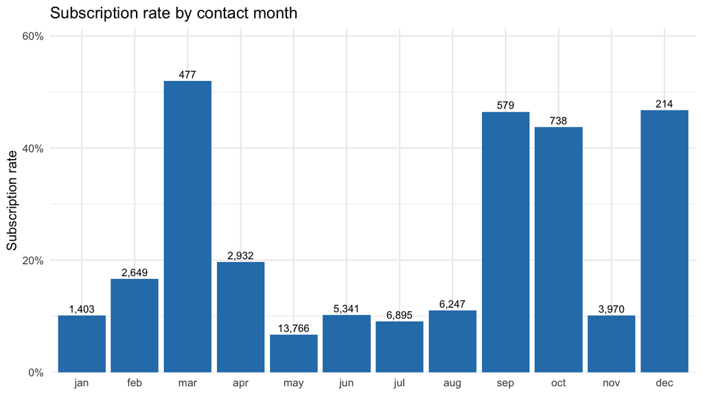

```r
month_levels <- c(
  "jan", "feb", "mar", "apr", "may", "jun",
  "jul", "aug", "sep", "oct", "nov", "dec"
)

bank_full %>%
  mutate(month = factor(month, levels = month_levels)) %>%
  group_by(month) %>%
  summarise(
    contacts = n(),
    subscribe_rate = mean(y == "yes"),
    .groups = "drop"
  ) %>%
  ggplot(aes(month, subscribe_rate)) +
  geom_col(fill = "#2c7fb8") +
  geom_text(aes(label = scales::comma(contacts)), vjust = -0.4, size = 3) +
  scale_y_continuous(
    labels = scales::percent,
    expand = expansion(mult = c(0, 0.18))
  ) +
  labs(
    title = "Subscription rate by contact month",
    x = NULL,
    y = "Subscription rate"
  ) +
  theme_minimal()
```

Instead of using a `set.seed()` function, the authors provided samples for both datasets.

Remaining EDA should bring in the additional columns in `Bank-additional-full.csv` if macro economics seem appropriate. Macro is a would-be-nice in objective 1, and only if additional predictive power is found in objective 2.

Suspecting a seasonal trend.

## Numerical predictors

The numeric predictors in `bank-full.csv` are `age`, `balance`, `day`, `duration`, `campaign`, `pdays`, and `previous`. The scatterplot matrix uses those seven columns from `bank_full` (n = 45,211). Each upper-triangle entry is the Pearson correlation. Each diagonal panel is a kernel density. Each lower-triangle panel is the pairwise scatterplot.

`pdays` equal to −1 means the client was not previously contacted, so a Pearson correlation that includes `pdays` treats that code as a day count. The right tails of `balance`, `duration`, `campaign`, and `previous` set the axis ranges in the panels that use those predictors.

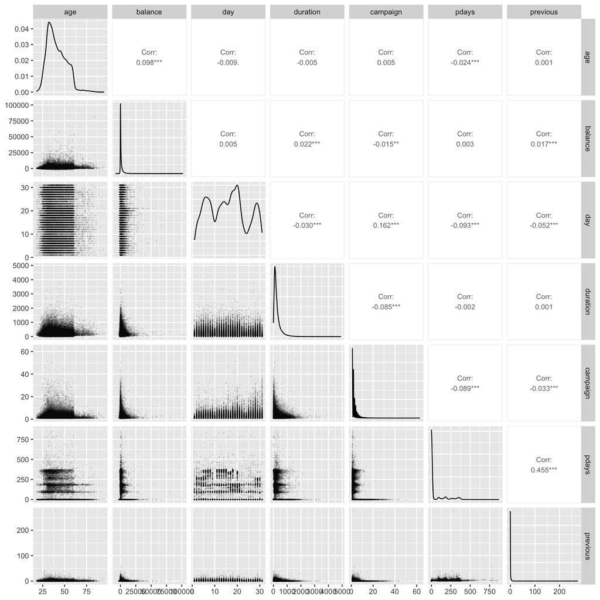

```r
library(GGally)

num_vars <- bank_full %>%
  select(where(is.numeric)) %>%
  names()

ggpairs(
  bank_full,
  columns = num_vars,
  upper = list(continuous = wrap("cor", size = 3)),
  lower = list(continuous = wrap("points", alpha = 0.05, size = 0.2)),
  diag = list(continuous = wrap("densityDiag", alpha = 0.4)),
  progress = FALSE
)
```

## Within-level subscription proportions

`bank-full.csv` supplies the counts below (n = 45,211). The first table is the marginal distribution of `y`. For a categorical predictor, `cnt` is the number of contacts at that level and that value of `y`, and `perc` equals `cnt` divided by the number of contacts in the level. Each bar shows `perc` for `y` equal to yes. `reorder()` places the highest within-level proportion at the left. The month chart above uses calendar order. The month bar in this section orders months by that proportion.

```r
bank_full %>%
  group_by(y) %>%
  summarise(cnt = n(), .groups = "drop") %>%
  mutate(perc = round(cnt / sum(cnt), 4))
```

| y | cnt | perc |
| --- | --- | --- |
| no | 39922 | 0.883 |
| yes | 5289 | 0.117 |

```
## # A tibble: 24 × 4
##    job          y       cnt   perc
##    <chr>        <chr> <int>  <dbl>
##  1 admin.       no     4540 0.878
##  2 admin.       yes     631 0.122
##  3 blue-collar  no     9024 0.927
##  4 blue-collar  yes     708 0.0727
##  5 entrepreneur no     1364 0.917
##  6 entrepreneur yes     123 0.0827
##  7 housemaid    no     1131 0.912
##  8 housemaid    yes     109 0.0879
##  9 management   no     8157 0.862
## 10 management   yes    1301 0.138
## # ℹ 14 more rows
```

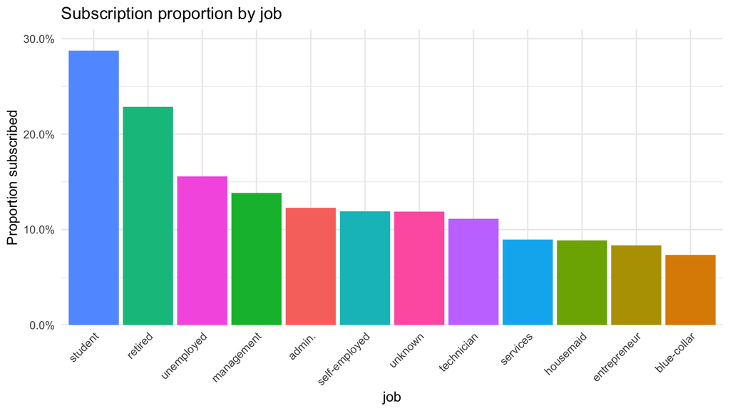

```
## # A tibble: 6 × 4
##   marital  y       cnt  perc
##   <chr>    <chr> <int> <dbl>
## 1 divorced no     4585 0.880
## 2 divorced yes     622 0.120
## 3 married  no    24459 0.899
## 4 married  yes    2755 0.101
## 5 single   no    10878 0.850
## 6 single   yes    1912 0.150
```

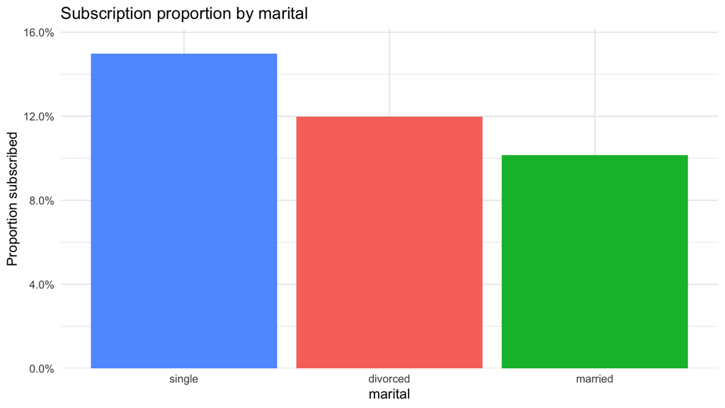

```
## # A tibble: 8 × 4
##   education y       cnt   perc
##   <chr>     <chr> <int>  <dbl>
## 1 primary   no     6260 0.914
## 2 primary   yes     591 0.0863
## 3 secondary no    20752 0.894
## 4 secondary yes    2450 0.106
## 5 tertiary  no    11305 0.850
## 6 tertiary  yes    1996 0.150
## 7 unknown   no     1605 0.864
## 8 unknown   yes     252 0.136
```

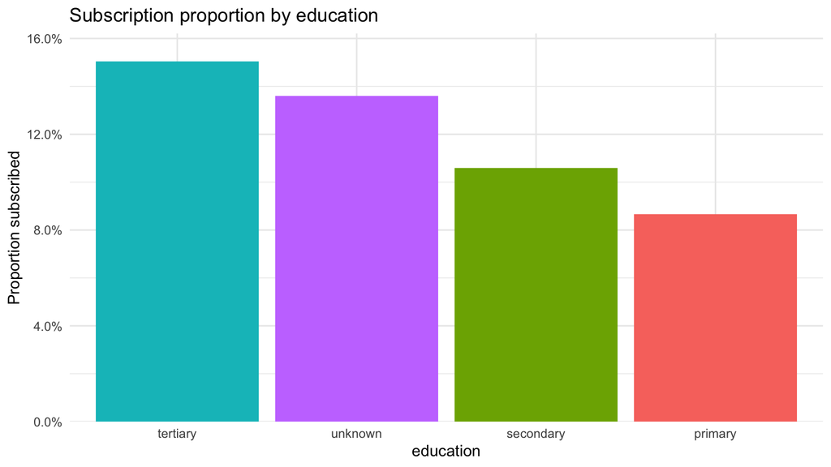

```
## # A tibble: 4 × 4
##   default y       cnt   perc
##   <chr>   <chr> <int>  <dbl>
## 1 no      no    39159 0.882
## 2 no      yes    5237 0.118
## 3 yes     no      763 0.936
## 4 yes     yes      52 0.0638
```

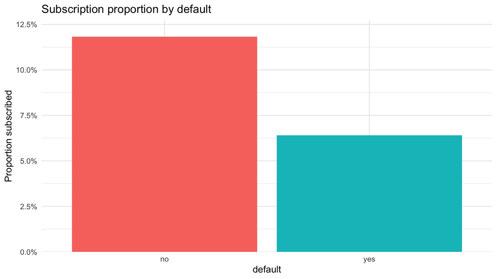

```
## # A tibble: 4 × 4
##   housing y       cnt  perc
##   <chr>   <chr> <int> <dbl>
## 1 no      no    16727 0.833
## 2 no      yes    3354 0.167
## 3 yes     no    23195 0.923
## 4 yes     yes    1935 0.077
```

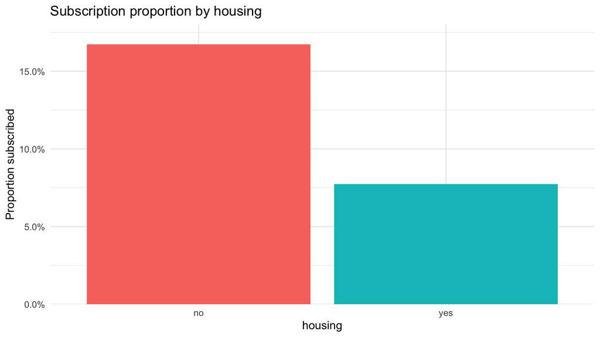

```
## # A tibble: 4 × 4
##   loan  y       cnt   perc
##   <chr> <chr> <int>  <dbl>
## 1 no    no    33162 0.873
## 2 no    yes    4805 0.127
## 3 yes   no     6760 0.933
## 4 yes   yes     484 0.0668
```

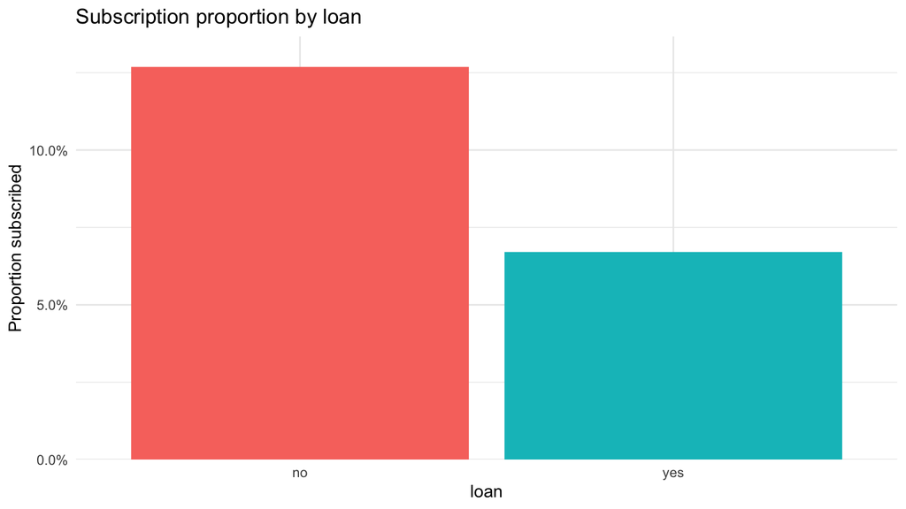

```
## # A tibble: 6 × 4
##   contact   y       cnt   perc
##   <chr>     <chr> <int>  <dbl>
## 1 cellular  no    24916 0.851
## 2 cellular  yes    4369 0.149
## 3 telephone no     2516 0.866
## 4 telephone yes     390 0.134
## 5 unknown   no    12490 0.959
## 6 unknown   yes     530 0.0407
```

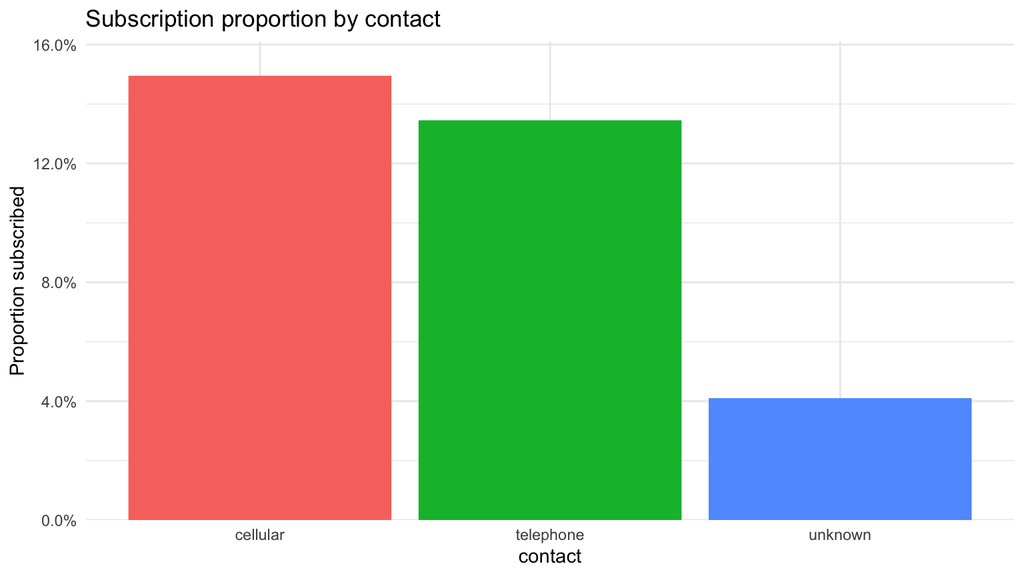

```
## # A tibble: 24 × 4
##    month y       cnt  perc
##    <chr> <chr> <int> <dbl>
##  1 apr   no     2355 0.803
##  2 apr   yes     577 0.197
##  3 aug   no     5559 0.890
##  4 aug   yes     688 0.110
##  5 dec   no      114 0.533
##  6 dec   yes     100 0.467
##  7 feb   no     2208 0.834
##  8 feb   yes     441 0.166
##  9 jan   no     1261 0.899
## 10 jan   yes     142 0.101
## # ℹ 14 more rows
```

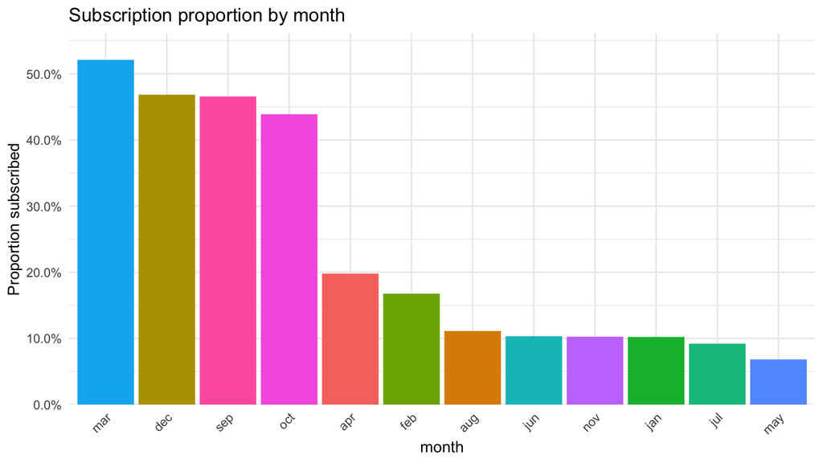

```
## # A tibble: 8 × 4
##   poutcome y       cnt   perc
##   <chr>    <chr> <int>  <dbl>
## 1 failure  no     4283 0.874
## 2 failure  yes     618 0.126
## 3 other    no     1533 0.833
## 4 other    yes     307 0.167
## 5 success  no      533 0.353
## 6 success  yes     978 0.647
## 7 unknown  no    33573 0.908
## 8 unknown  yes    3386 0.0916
```

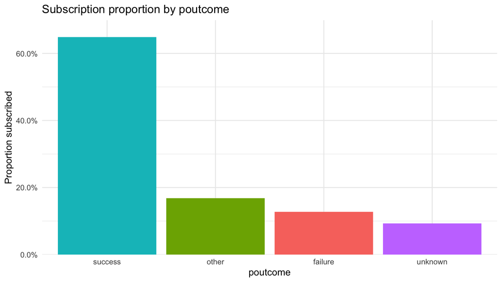

```r
cat_vars <- bank_full %>%
  select(where(is.character), -y) %>%
  names()

for (var in cat_vars) {
  tab <- bank_full %>%
    group_by(.data[[var]], y) %>%
    summarise(cnt = n(), .groups = "drop_last") %>%
    mutate(perc = round(cnt / sum(cnt), 4)) %>%
    ungroup()

  print(tab)

  angle <- if (dplyr::n_distinct(tab[[var]]) > 4) 45 else 0

  p <- ggplot(
    filter(tab, y == "yes"),
    aes(
      x = reorder(.data[[var]], -perc),
      y = perc,
      colour = .data[[var]]
    )
  ) +
    geom_bar(
      aes(fill = .data[[var]]),
      stat = "identity",
      show.legend = FALSE
    ) +
    scale_y_continuous(
      labels = scales::percent_format(accuracy = 0.1),
      expand = expansion(mult = c(0, 0.08))
    ) +
    labs(
      title = paste("Subscription proportion by", var),
      x = var,
      y = "Proportion subscribed"
    ) +
    theme_minimal() +
    theme(
      axis.text.x = element_text(
        angle = angle,
        hjust = if (angle > 0) 1 else 0.5
      )
    )

  print(p)
}
```